# Impact of severe weather on the power grid

Author

Lauren Puffer

Published

November 9, 2025

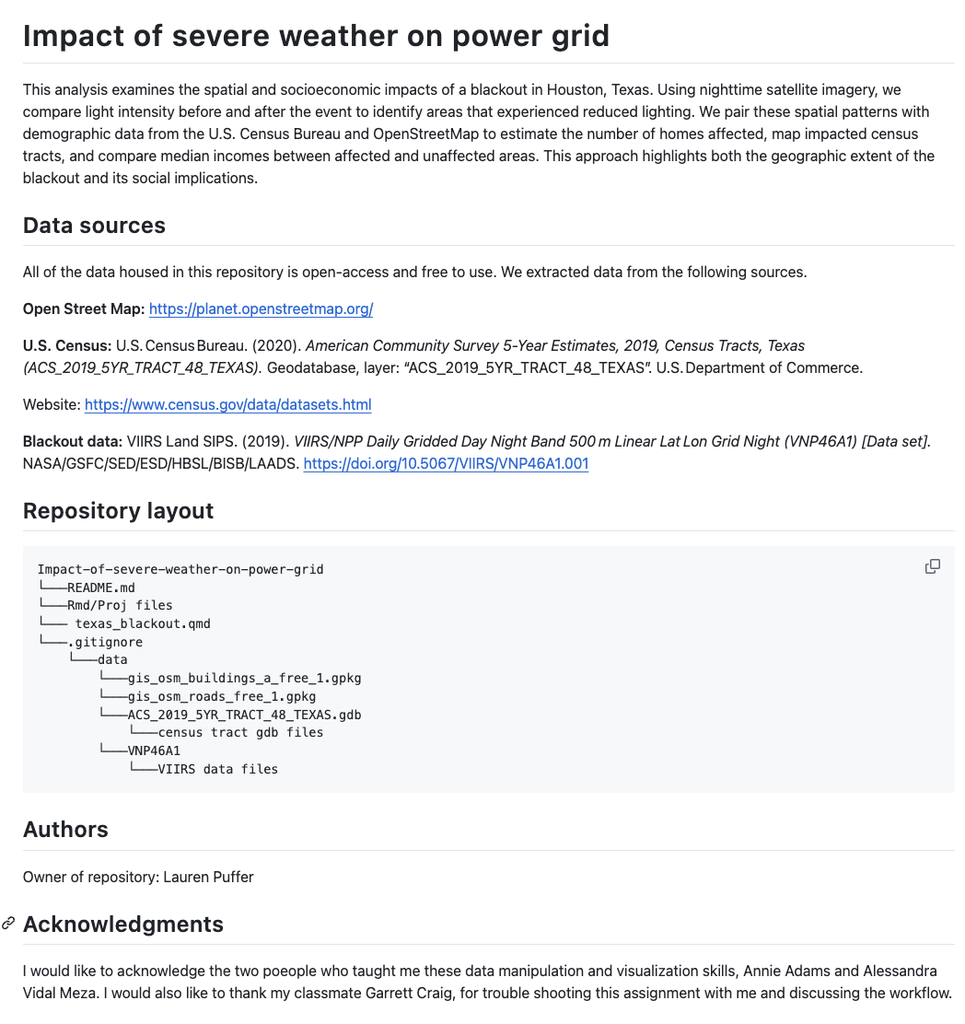

# Introduction

This analysis investigates the spatial and socioeconomic impact of a blackout event in Houston, Texas. Using nighttime light satellite imagery, we quantify changes in light intensity by comparing data from before the blackout to data from after. By calculating the difference in light intensity, we can identify which areas experienced reduced lighting and are likely to have been affected by the blackout.

To understand the social implications of the blackout, we use these spatial observations with demographic data from the U.S. Census Bureau and Open Street Map. We want to know the number of homes impacted, make a map of the affected census tracts, and examine the median income of residents in tracts affected by the blackout versus those that were not. This approach allows us to assess both the spatial distribution and the socioeconomic factors of the blackout’s impact, providing insights into infrastructure capacity and social equity.

# Data Sources

**Open Street Map:** https://planet.openstreetmap.org/

**U.S. Census:** U.S. Census Bureau. (2020). *American Community Survey 5‑Year Estimates, 2019, Census Tracts, Texas (ACS_2019_5YR_TRACT_48_TEXAS).* Geodatabase, layer: “ACS_2019_5YR_TRACT_48_TEXAS”. U.S. Department of Commerce.

Website: https://www.census.gov/data/datasets.html

**Blackout data:** VIIRS Land SIPS. (2019). *VIIRS/NPP Daily Gridded Day Night Band 500 m Linear Lat Lon Grid Night (VNP46A1) [Data set].* NASA/GSFC/SED/ESD/HBSL/BISB/LAADS. https://doi.org/10.5067/VIIRS/VNP46A1.001

# Load packages

```r
library(terra)
library(tmap)
library(here)
library(janitor)
library(tidyverse)
library(kableExtra) # table formatting
library(spData) # spatial data
library(spDataLarge) # spatial data
library(geodata)
library(stars)
library(viridisLite) # for colorblind friendy visuals
```

# Load data

## Light raster of Houston, TX

Raster data of light intensity from before (February 7th, 2021) and after (February 16th, 2021) is contained in the following rasters. Because Houston is such a large city, we must bring two “tiles” together to create a complete map of the cities light intensity on these two days.

```r
# read tile at 10:38 from Feb 7th 2021 in Houston
houston05_02_07 <- read_stars(here("data", "VNP46A1", "VNP46A1.A2021038.h08v05.001.2021039064328.tif"), quiet = TRUE)

# read tile at 10:38 from Feb 7th 2021 in Houston
houston06_02_07 <- read_stars(here("data", "VNP46A1", "VNP46A1.A2021038.h08v06.001.2021039064329.tif"), quiet = TRUE)

# read tile at 10:47 from Feb 16th 2021 in Houston
houston05_02_16 <- read_stars(here("data", "VNP46A1", "VNP46A1.A2021047.h08v05.001.2021048091106.tif"), quiet = TRUE)

# read tile at 10:47 from Feb 16th 2021 in Houston
houston06_02_16 <- read_stars(here("data", "VNP46A1", "VNP46A1.A2021047.h08v06.001.2021048091105.tif"), quiet = TRUE)
```

## Combine tiles by date

We must first combine the February 7th and February 16th rasters, as they both represent contain parts of the city.

```r
# combine feb 7th rasters
feb_7_combined <- st_mosaic(houston06_02_07, houston05_02_07)

# combine feb 16th rasters
feb_16_combined <- st_mosaic(houston06_02_16, houston05_02_16)
```

## Roads vector of Houston, TX

```r
# get roads as a vector
roads <- st_read(here("data", "gis_osm_roads_free_1.gpkg"),
                 query = "SELECT * FROM gis_osm_roads_free_1 WHERE fclass='motorway'",
                 quiet = TRUE)
```

## Buildings

Our buildings vector, like our roads vector, also comes from Open Street Map. These data will come in as polygons.

```r
# get buildings as a vector
buildings <- st_read(here("data", "gis_osm_buildings_a_free_1.gpkg"),
                     query = "SELECT * FROM gis_osm_buildings_a_free_1 WHERE (type IS NULL AND name IS NULL) OR type in ('residential', 'apartments', 'house','static_caravan', 'detached')",
                     quiet= TRUE)
```

## Census data from Texas

We will need to use a datasbase that has geometries and combine it with our ‘census’ dataframe. Our ‘census’ datafram contains GEOID’s which will allow us to join with another dataset conatining the correct geometries needed to check the CRS and complete our analysis.

```r
# get list of layers in .gdb
st_layers(here("data", "ACS_2019_5YR_TRACT_48_TEXAS.gdb")) # X19_INCOME will be used
```

```
Driver: OpenFileGDB
Available layers:
                            layer_name geometry_type features fields crs_name
1                      X01_AGE_AND_SEX            NA     5265    719     <NA>
2                             X02_RACE            NA     5265    433     <NA>
3        X03_HISPANIC_OR_LATINO_ORIGIN            NA     5265    111     <NA>
4                         X04_ANCESTRY            NA     5265    665     <NA>
5         X05_FOREIGN_BORN_CITIZENSHIP            NA     5265   1765     <NA>
6                   X06_PLACE_OF_BIRTH            NA     5265   1221     <NA>
7                        X07_MIGRATION            NA     5265   1793     <NA>
8                        X08_COMMUTING            NA     5265   2541     <NA>
9  X09_CHILDREN_HOUSEHOLD_RELATIONSHIP            NA     5265    263     <NA>
10      X10_GRANDPARENTS_GRANDCHILDREN            NA     5265    373     <NA>
11    X11_HOUSEHOLD_FAMILY_SUBFAMILIES            NA     5265    781     <NA>
12      X12_MARITAL_STATUS_AND_HISTORY            NA     5265    759     <NA>
```

[output cut: 20 more lines]

```r
# load census geopackage for 2019
census_geo <- st_read(here("data", "ACS_2019_5YR_TRACT_48_TEXAS.gdb"),
                  layer = "ACS_2019_5YR_TRACT_48_Texas",
                  quiet = TRUE)|>
  st_make_valid()

# load census income for 2019
census_income <- st_read(here("data", "ACS_2019_5YR_TRACT_48_TEXAS.gdb"),
                  layer = "X19_INCOME",
                  quiet = TRUE)

# remove all digits from GEOID but the last 11
census_income <- census_income |>
  mutate(GEOID = str_replace(GEOID, "^14000US", ""))

# left join income and geometry
census_join <- left_join(census_geo, census_income, by = "GEOID")
```

# Coordinate Reference Systems

In order to ensure that all of our data is compatible spatially, we must make sure that they are all using the same Coordinate Reference System. Some spatial data is stored based on different maps or different units. For example, one dataset may be using meters for spatial data, while another is using degrees.

To ensure that our spatial data matches in CRS, we will first have to check what the CRS’s are for each.

## Checking CRSs

Assuming all of the tile data are in the same CRS, we will test the CRS of one of them.

```r
# check that tiles match
st_crs(houston06_02_07) == st_crs(houston05_02_16) # they do!
```

The Houston light data uses WGS 84 (EPSG 4326). We will match all of our other data to this CRS using the st_transform() function.

Now we will transform our roads sf to match the CRS of the Houston light data (EPSG 4326).

```r
# double check that they are an exact match
st_crs(roads) == st_crs(houston06_02_16) # true!
```

## Change CRSs to match

```r
# check to see if the census data has a CRS
crs_check_roads <- st_crs(census_join) == st_crs(roads) # false

# check and transform CRS
if(st_crs(census_join) == st_crs(houston05_02_07)){
  print("Coordinate reference systems match.")
}else{
  warning("Updating coordinate reference systems to match.")
  #transform data to match
  census_join_reproj <- st_transform(census_join, st_crs(houston05_02_07))
}
```

Now that all of the CRSs match for all of our data, we can begin our data manipulations to prepare them for analysis.

# Houston blackout map

To better understand which areas were impacted by the February 16th blackout, we will subtract the cell values in our light intensity tiles from before and after the blackout to get the difference.

## Plot of light intensity before and after the storm

We will plot the light intensity map before and after the blackout. To do this, we will use the plot() function.

First, we will create a bounding box for the city of Houston to crop our stars rasters to.

```r
# create bbox for the city of Houston
houston_boundary <- st_bbox(c(
  xmin = -96.5,
  ymin = 29,
  xmax = -94.5,
  ymax = 30.5
), crs = st_crs(4326))  # WGS84 lon/lat

# vectorize the boundary
houston <- st_as_sfc(houston_boundary)
```

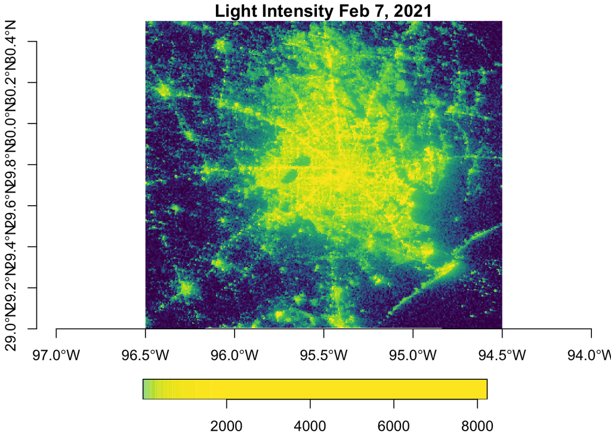

```r
# crop february 7 raster to Houston extent
feb_7_cropped <- st_crop(feb_7_combined, houston)

# crop february 16 raster to Houston extent
feb_16_cropped <- st_crop(feb_16_combined, houston)

# create 1 row with 2 columns
par(mfrow = c(1, 2))

# plot of february 7th 2021 light intesnity
plot(feb_7_cropped,
     col = viridis(256),
     main = "Light Intensity Feb 7, 2021",
     axes = TRUE)
```

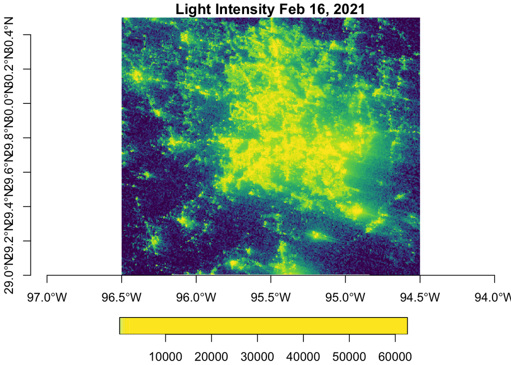

```r
# plot of february 16th 2021 light intesnity
plot(feb_16_cropped,
     col = viridis(256),
     main = "Light Intensity Feb 16, 2021",
     axes = TRUE)
```

```r
par(mfrow = c(1, 1))
```

You can see in the two images that much of the street lights went out in the Houston area. Light intensity became much more patchy in the central part of Houston after the blackout occurred. Most of the intensity shown in the scale bar is on the higher end, with little to no light intensity being dark blue.

## Difference in light intensity

In order to see the severity of the blackout by looking at the difference between light intensity before and after the blackout. We will do this by subtracting the cell values from the blackout date, from the cell values the week before (February 7th).

```r
# get the difference
difference <- feb_7_combined - feb_16_combined

# make any values with <200 an NA
difference[difference <= 200] <- NA
```

Now we need to make a vector of the difference so that we can create a mask of areas which were impacted by the blackout.

```r
# create a vector of the difference
mask_sf <- st_as_sf(difference, as_points = FALSE, merge = TRUE) |>
  st_make_valid()
```

## Crop blackout mask

We will use st_intersects() with the Houston boundary box and the difference mask to get the areas that are within the boundary.

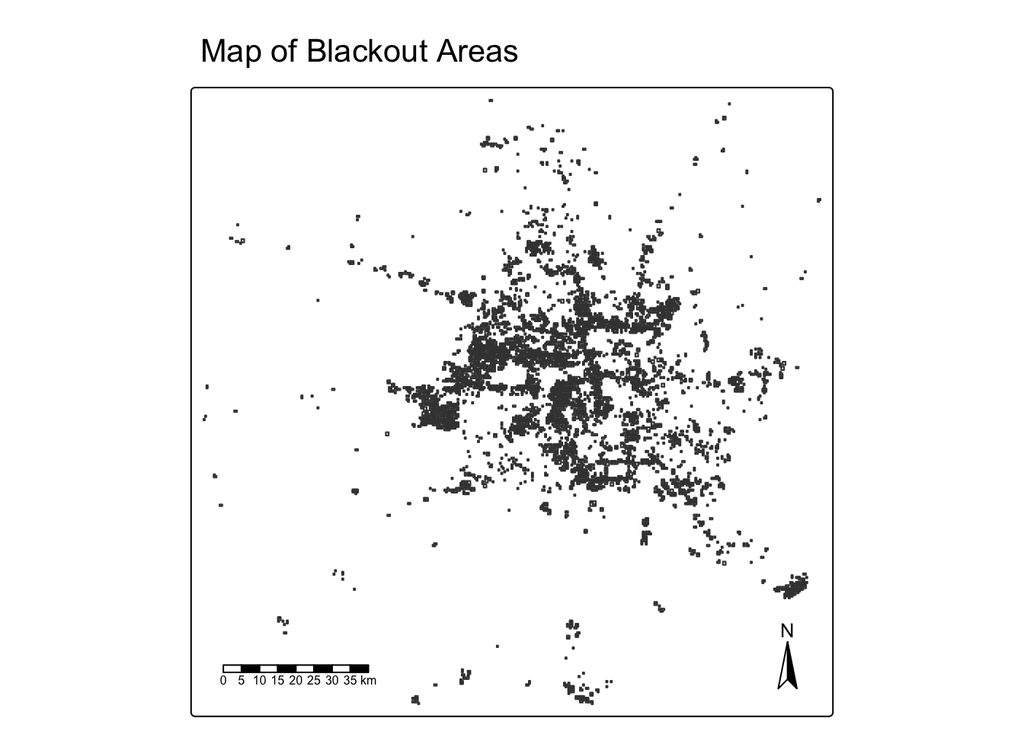

```r
# get crs of mask
crs_mask <- st_crs(mask_sf) # 4326

# use st_intersects() to get just the area of blackout difference in the bbox
blackout_houston <- mask_sf[mask_sf |>
                              st_intersects(houston, sparse = FALSE), ]

# show all areas where >200 difference
tm_shape(blackout_houston)+
  tm_polygons() +
  tm_scale_bar(position = c("left", "bottom"))+
  tm_compass()+
  tm_title(text = "Map of Blackout Areas")
```

Now that we have a map of more intense blackouts, we can bring in the roads data and exclude any polygons within 200m of the road.

## Change CRS to meters

We have a roads vector which shares the same CRS as our other data, but because we want to create a buffer that is in meters, we have to change the CRS. Houston, TX uses EPSG 3083. We should be able to preserve the spatial data we have and convert to EPSG 3083 from WGS 84 (EPSG 4326).

```r
# check roads CRS
st_crs(roads) # EPSG 4326

# change to a CRS that uses meters
roads_trans <- st_transform(roads, crs = 3083)

# check the CRS of "blackout_houston"
st_crs(blackout_houston) # 4326

# change CRS to match "roads_trans"
blackout_houston_trans <- st_transform(blackout_houston, crs = 3083)
```

## Creating a 200m buffer around roads

Now that our roads and blackout polygons are both both in CRSs that use meters, we must add a buffer to our roads. In order to do this, we must make them into a vector. We will do this by “expanding” the geometry of the roads to 200m.

```r
# create 200 m buffer around roads
roads_buffer_200m <- st_buffer(roads_trans, dist = units :: set_units(200, "m"))

# use st_union() to bombine roads and buffers
roads_union <- st_union(roads_buffer_200m)
```

## Exclude polygons touching roads

```r
# check classes
class(roads_union) # multipolygon
class(blackout_houston_trans) # sf

# check CRS
st_crs(blackout_houston_trans) == st_crs(roads_union) # EPSG 3083

# get list of polygons that don't intersect
disjoint_index <- st_disjoint(blackout_houston_trans, roads_union)
# anything with a 0 in this list intersects with roads

# make logic out of list
disjoint_logical <- lengths(disjoint_index) != 0

# keep polygons that don't intersect with 200 m roads buffer
no_roads_blackout <- blackout_houston_trans[disjoint_logical, ]
```

# Map of homes that lost power

Now, we want to see which homes lost power from the storm. Since we already have a map of polygons with strong differences in light intensity, we can use st_intersects to keep only the homes and bulidings that overlap with the areas of strong power loss.

## Convert back to EPSG 4326

Because we had to create a buffer in meters, our no_roads_blackout sf is no loner in EPSG 4326, but is instead in EPSG 3083. We will fix this by converting it back right now.

```r
# convert blackout map back to 4326
no_roads_blackout_trans <- st_transform(no_roads_blackout, crs = 4326)

# reproject buildings

# check to make sure it matches 'buildings'
st_crs(no_roads_blackout_trans) == st_crs(buildings) # true!
```

Now that our CRSs match, we can find homes and buildings that overlap with our blackout areas. This will allow us to get both a map of the homes that experienced blackout, and a total # of homes that experienced blackout as well.

```r
# get buildings that intersect the no_roads polygons
blackout_buildings <- buildings |>
  st_filter(y = no_roads_blackout_trans, .predicate = st_intersects)

# get the sum of homes that experienced blackout
cat("Number of buildings with blackout:", nrow(blackout_buildings), "\n")
```

```
Number of buildings with blackout: 133804
```

The total number of homes affected by the blackout was **133,804**. This is also the number of observations we had in our “blackout_buildings” sf. Each building is one polygon in the ‘geometry’ column.

## Map of homes that lost power

Now, we can use tmap to create a map of the homes that lost their power as a result of the February storms in Houston, TX.

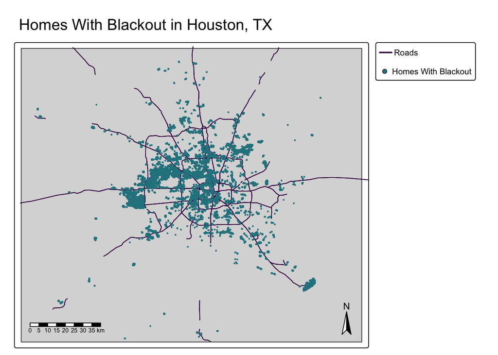

```r
# plot map of blackout_buildings
tm_shape(houston)+
  tm_polygons()+
  tm_shape(roads)+
  tm_lines(col = "#440154")+
  tm_shape(blackout_buildings)+
  tm_bubbles(size = 0.1,
          col = "#26828E")+
  tm_title(text = "Homes With Blackout in Houston, TX")+
  tm_scalebar(position = "bottom")+
  tm_compass()+
    tm_add_legend(
    type = "line",
    labels = "Roads",
    col = "#440154",
    lwd = 2
  ) +
  tm_add_legend(
    type = "symbol",
    labels = "Homes With Blackout",
    col = "#26828E",
    size = 0.4
  ) +
  tm_layout(legend.outside = TRUE)
```

# Median income of households

Next, we would like to know what the median income of households experiencing blackout was. To do this, we want to get the census tract data of homes that experienced blackouts. We will use the U.S. Census data we have for spatial information of the census tract each home belongs to, and get income information from that data. The median income of all homes experiencing blackout will require us to assign a median household income to each home, according to which census tract it belongs to.

## Census tracts that lost power

Now we can create a map of census tracts which lost power. We will do this by filtering the census tract polygons to include those that have overlapping geometries with buildings that experienced blackout.

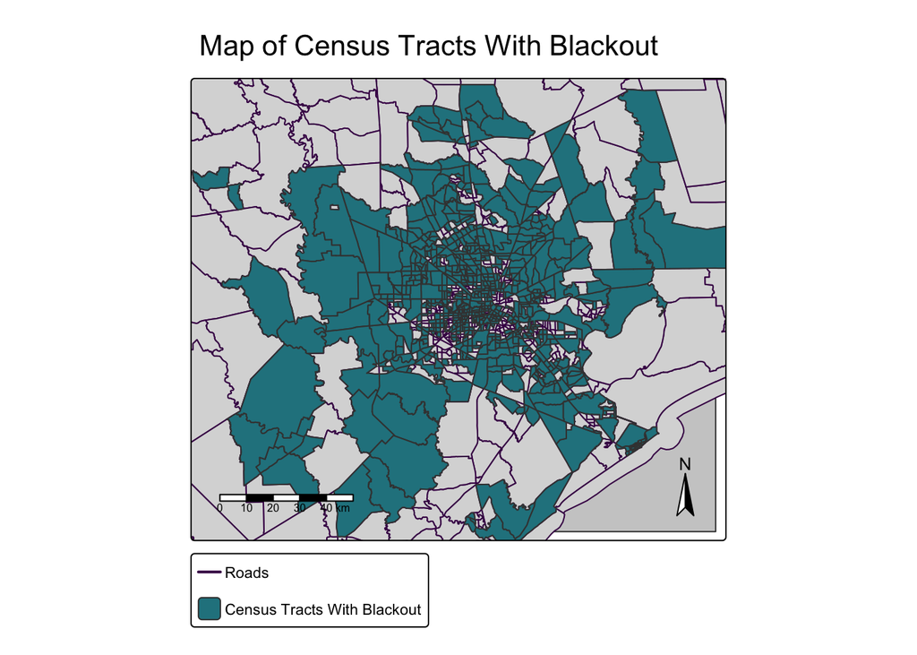

```r
#check CRS now
crs_check <- st_crs(census_join_reproj) == st_crs(blackout_buildings) # true!

# get tracts with buildings in them
census_blackout <- census_join_reproj |>
  st_filter(y = blackout_buildings, .predicate = st_intersects)


# plot using tmap
tm_shape(houston)+
  tm_polygons("grey80")+
  tm_shape(census_join_reproj)+
  tm_polygons(col = "#440154")+
  tm_shape(census_blackout)+
  tm_polygons(fill = "#26828E")+
  tm_title(text = "Map of Census Tracts With Blackout")+
  tm_scalebar(position = "bottom")+
  tm_compass()+
      tm_add_legend(
    type = "line",
    labels = "Roads",
    col = "#440154",
    lwd = 2
  ) +
  tm_add_legend(
    type = "fill",
    labels = "Census Tracts With Blackout",
    col = "#26828E",
    size = 0.4
  ) +
  tm_layout(legend.outside = TRUE)
```

As we can see, there were quite a few census tracts that experienced blackouts. While not every resident in these areas experienced blackout, we can see that the impact of the storms covered a very large area of the city.

## Median income of blackout homes

We will use ggplot to visualize the distribution of median household income for census tracts that lost power. First, we must create a column in our income_join_reproj for blackouts that is yes/no. Then we must dissolve the geometries.

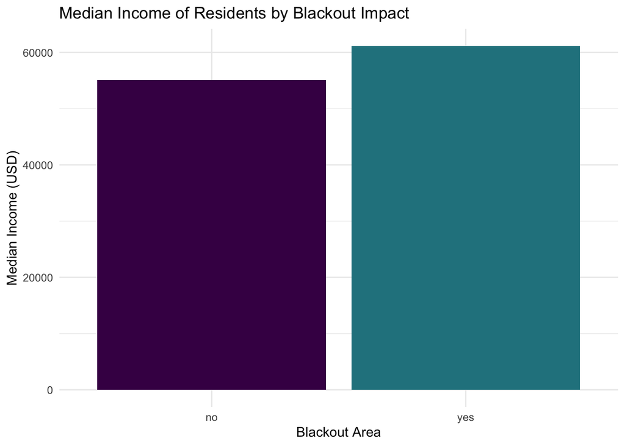

```r
# make column of yes/no for if the census experienced a blackout or not
census_join_reproj <- census_join_reproj |>
  mutate(in_blackout = if_else(GEOID %in% census_blackout$GEOID, "yes", "no"))

# dissolve geometries, group by blackout y/n, and calculate the mean
census_join_reproj_df <- census_join_reproj |>
  st_drop_geometry() |>
  group_by(in_blackout)|>
  summarise(median_value = median(B19013e1, na.rm = TRUE))

# try this
median_income_plot <- ggplot(census_join_reproj_df,
                             aes(x = in_blackout, y = median_value, fill = in_blackout)) +
  geom_col() +
    scale_fill_manual(values = c("yes" = "#26828E",    # blackout
                               "no" = "#440154")) + # no blackout
  labs(x = "Blackout Area",
       y = "Median Income (USD)",
       title = "Median Income of Residents by Blackout Impact") +
  theme_minimal() +
  theme(legend.position = "none")

# show the plot
print(median_income_plot)
```

# Discussion

There is not a large difference in the economic status of people in Houston, Texas who experienced blackout vs. those who did not.Those that experienced blackout actually had median incomes which were moderately higher than those that didn’t. Ultimately, this blackout is affecting people across socioeconomic status. One thing which may impact residents in the future, is the cost of home and auto insurance following the storm. The storms in February of 2021 in Houston created a loss of between 10 and 20 billion dollars for insured residents, making it one of the most expensive storms in the state’s history (Cappelletti, 2021). That number was later revised to be up tp 200 billion dollars if you factor in the cost to the energy sector (Ivanova, 2021). Much of the loss of energy could be experienced in publicly owned utilities like street lamps. However, our analysis has focused primarily on residential loss, so we cannot say for certain if that is truly the case. The storm event in Houston in February of 2021 seemed to have a much more widespread impact across socioeconomic status than say Hurricane Katrina, which devastated much of the black community, people experiencing poverty, and elderly citizens (Gabe, McCarty, & Falk, 2005). If the impact were similar to Hurricane Katrina, we would have seen the median income of those impacted being noticeably lower than those that did not experience a blackout for example.

## References

Cappelletti, A. (2021, June). *Texas Winter Storm 2021: Accounting for subsequent events*. General Insurance Section News, June 2021. Society of Actuaries. [https://www.soa.org/news-and-publications/newsletters/general-insurance/2021/june/gii-2021-06/texas-winter-storm-2021-accounting-for-subsequent-events/](https://www.soa.org/news-and-publications/newsletters/general-insurance/2021/june/gii-2021-06/texas-winter-storm-2021-accounting-for-subsequent-events/?utm_source=chatgpt.com)

Gabe, T., McCarty, M., & Falk, G. (2005, November 4). Hurricane Katrina: Social‑demographic characteristics of impacted areas (CRS Report No. RL33141). Congressional Research Service. https://www.everycrsreport.com/reports/RL33141.html

Ivanova, I. (2021, February 19). *Texas winter storm costs could top $200 billion — more than hurricanes Harvey and Ike*. CBS News. [https://www.cbsnews.com/news/texas-winter-storm-uri-costs/](https://www.cbsnews.com/news/texas-winter-storm-uri-costs/?utm_source=chatgpt.com)